# Spatial Autocorrelation: Global and Local Moran’s I

- Show All Code
- Hide All Code
- View Source

Do high SIRs sit next to high SIRs?

Author

Eric M. Delmelle · Lehigh University

**Get the source.** [Download `index.qmd`](https://github.com/BSTA-374/MoranI/raw/main/index.qmd) — open it in RStudio and run the chunks alongside this page.

## Where we left off

Last time we turned Pennsylvania’s lung cancer cases into expected counts and SIRs. Looking at the SIR map, the eye starts to see patterns: a darker patch here, a lighter one there. Today we ask whether those patterns are real, in two steps.

1. **Global Moran’s I** — one number for the whole state: do similar SIRs tend to sit next to each other?
2. **Local Moran’s I (LISA)** — one number per county: *where* are the clusters and the outliers?

Between the two, we use **simulation** to decide what “more clustered than chance” means. Reading: **Rogerson & Yamada Ch. 3–4**.

```r
library(sf)
library(dplyr)
library(ggplot2)
library(patchwork)
library(spdep)        # neighbours, weights, Moran's I
library(SpatialEpi)   # pennLC data

theme_set(theme_classic(base_size = 12))
```

**Note**

If `spdep` is missing, `install.packages("spdep")` once.

# 1 Back to the SIR map

We rebuild the observed and expected counts from last lecture in one chunk.

```r
data(pennLC)
d <- pennLC$data

ref <- d |>
  group_by(race, gender, age) |>
  summarise(r = sum(cases) / sum(population), .groups = "drop")   # 16 reference rates

county <- d |>
  left_join(ref, by = c("race", "gender", "age")) |>
  group_by(county) |>
  summarise(O = sum(cases), E = sum(population * r), .groups = "drop") |>
  mutate(SIR = O / E)

pa <- st_as_sf(pennLC$spatial.polygon) |>
  st_set_crs(4326) |>
  mutate(county = names(pennLC$spatial.polygon)) |>
  st_transform(5070) |>                                           # Albers, metres
  left_join(county, by = "county")

sir_breaks <- c(0, 0.67, 0.83, 0.95, 1.05, 1.2, 1.5, Inf)
sir_fill   <- scale_fill_brewer(palette = "RdBu", direction = -1, drop = FALSE, name = "SIR")
```

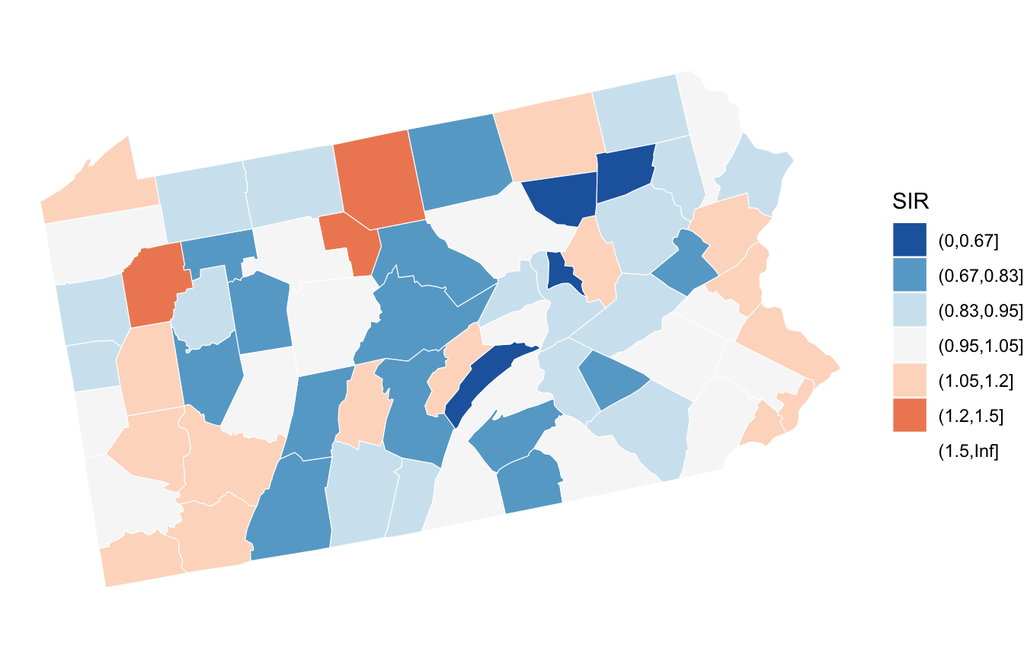

Figure 1: Raw SIRs for lung cancer, Pennsylvania 2002.

```r
ggplot(pa) +
  geom_sf(aes(fill = cut(SIR, sir_breaks)), colour = "white", linewidth = 0.2) +
  sir_fill +
  theme_void()
```

Our eyes are good at finding patterns, including ones that are not there. We need (a) a definition of “nearby” and (b) a measure of how similar nearby values are.

# 2 Who is a neighbour?

## 2.1 Queen contiguity

Two counties are neighbours if they share a border or even a single corner (like the queen in chess). `poly2nb()` builds the list.

```r
nb <- poly2nb(pa, queen = TRUE)
summary(card(nb))                               # neighbours per county
```

```
   Min. 1st Qu.  Median    Mean 3rd Qu.    Max.
  2.000   4.000   5.000   5.164   6.000   9.000
```

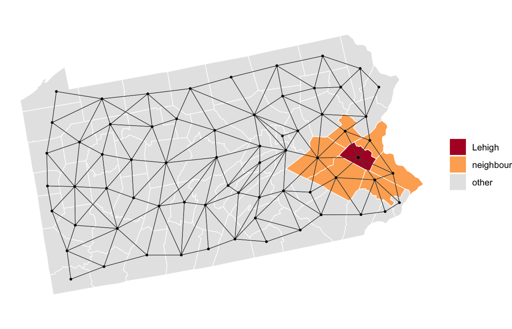

Figure 2: Queen-contiguity links between county centres. Lehigh and its neighbours are highlighted.

```r
pts   <- st_point_on_surface(st_geometry(pa))
links <- nb2lines(nb, coords = pts, as_sf = TRUE) |>
  st_set_crs(st_crs(pa))

i_leh <- which(pa$county == "lehigh")
pa$role <- "other"
pa$role[nb[[i_leh]]] <- "neighbour"
pa$role[i_leh] <- "Lehigh"

ggplot() +
  geom_sf(data = pa, aes(fill = role), colour = "white", linewidth = 0.3) +
  geom_sf(data = links, colour = "grey30", linewidth = 0.25) +
  geom_sf(data = pts, size = 0.6) +
  scale_fill_manual(values = c(Lehigh = "#b2182b", neighbour = "#fdae61", other = "grey90"),
                    name = NULL) +
  theme_void()
```

Other choices exist — rook contiguity (shared edges only), the *k* nearest centroids, or a distance band — and the answer can depend on the choice. Contiguity is the usual default for counties.

## 2.2 Row-standardized weights

We turn the list into weights. With `style = "W"`, each county’s neighbours get equal weight and the weights sum to 1, so “the neighbours’ value” is simply their **average**.

```r
lw <- nb2listw(nb, style = "W")

lw$weights[[i_leh]]                             # Lehigh: equal shares
```

```
[1] 0.1666667 0.1666667 0.1666667 0.1666667 0.1666667 0.1666667
```

## 2.3 The spatial lag

The **spatial lag** of a county is the average SIR of its neighbours. Mapping it next to the SIR is the most intuitive way to see autocorrelation: if the two maps look alike, neighbours resemble each other.

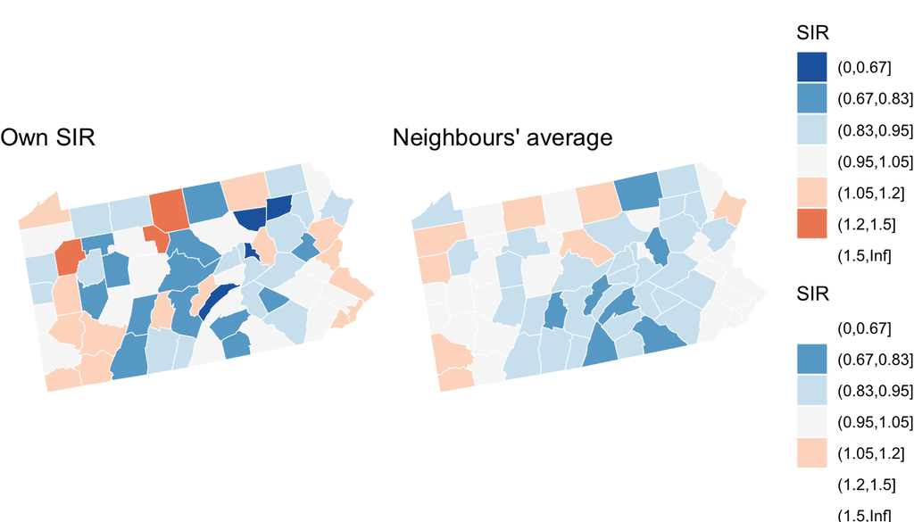

Figure 3: Each county’s own SIR (left) and the average SIR of its neighbours (right).

```r
pa$SIR_lag <- lag.listw(lw, pa$SIR)

m_own <- ggplot(pa) +
  geom_sf(aes(fill = cut(SIR, sir_breaks)), colour = "white", linewidth = 0.2) +
  sir_fill + labs(title = "Own SIR")

m_lag <- ggplot(pa) +
  geom_sf(aes(fill = cut(SIR_lag, sir_breaks)), colour = "white", linewidth = 0.2) +
  sir_fill + labs(title = "Neighbours' average")

(m_own | m_lag) + plot_layout(guides = "collect") & theme_void()
```

The lag map is smoother, as averages always are. The question is whether high-SIR counties tend to have high-SIR neighbours.

# 3 Global Moran’s I

## 3.1 The Moran scatterplot

Plot each county’s (standardized) SIR against its neighbours’ average.

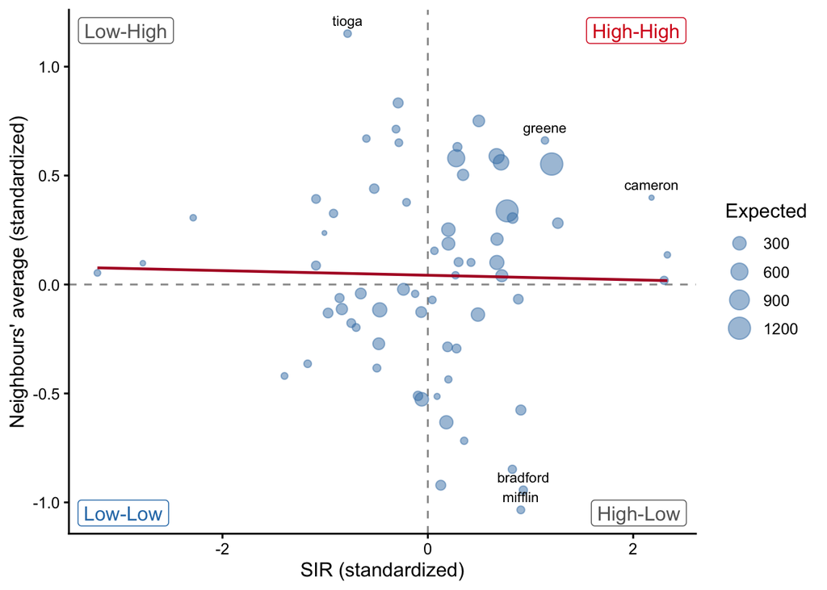

Figure 4: Moran scatterplot. The slope of the line is Moran’s I.

```r
pa <- pa |>
  mutate(z     = as.numeric(scale(SIR)),        # standardized SIR
         z_lag = lag.listw(lw, z))              # neighbours' average

ggplot(pa, aes(z, z_lag)) +
  geom_hline(yintercept = 0, linetype = "dashed", colour = "grey60") +
  geom_vline(xintercept = 0, linetype = "dashed", colour = "grey60") +
  geom_point(aes(size = E), alpha = 0.5, colour = "steelblue") +
  geom_smooth(method = "lm", se = FALSE, colour = "#b2182b", linewidth = 0.8) +
  geom_text(data = \(x) slice_max(x, abs(z * z_lag), n = 5),
            aes(label = county), size = 3, vjust = -0.8) +
  annotate("label", x = Inf, y = Inf, label = "High-High", hjust = 1.1, vjust = 1.3, colour = "#d7191c") +
  annotate("label", x = -Inf, y = -Inf, label = "Low-Low", hjust = -0.1, vjust = -0.3, colour = "#2c7bb6") +
  annotate("label", x = Inf, y = -Inf, label = "High-Low", hjust = 1.1, vjust = -0.3, colour = "grey40") +
  annotate("label", x = -Inf, y = Inf, label = "Low-High", hjust = -0.1, vjust = 1.3, colour = "grey40") +
  labs(x = "SIR (standardized)", y = "Neighbours' average (standardized)", size = "Expected")
```

Points in the **High-High** and **Low-Low** quadrants push the slope up (similar neighbours); points in **High-Low** and **Low-High** pull it down (dissimilar neighbours). With row-standardized weights, the slope of this line *is* Moran’s I.

## 3.2 The statistic

$$I = \frac{n}{\sum_i\sum_j w_{ij}} \cdot
\frac{\sum_i \sum_j w_{ij}\,(x_i-\bar x)(x_j-\bar x)}{\sum_i (x_i-\bar x)^2}$$

Read it as a correlation between each value and its neighbours’ values. Values near 0 suggest no pattern (strictly, the null expectation is $-1/(n-1)$, about $-0.015$ for 67 counties); positive values mean similar values cluster; negative values mean a checkerboard, which is rare for disease data.

```r
mi <- moran.test(pa$SIR, lw)

c(slope     = unname(coef(lm(z_lag ~ z, data = pa))[2]),
  Moran_I   = unname(mi$estimate[1]),
  expected  = unname(mi$estimate[2]))
```

```
      slope     Moran_I    expected
-0.01055968 -0.01055968 -0.01515152
```

The two numbers agree: Moran’s I for lung cancer SIRs is -0.011. Is that large? On its own, we cannot tell. That is what simulation is for.

# 4 Is it more than chance? Simulation

## 4.1 Shuffle the map

The null hypothesis says location does not matter: any county could have had any SIR. So we **shuffle** the 67 SIRs at random across the counties and look at the result.

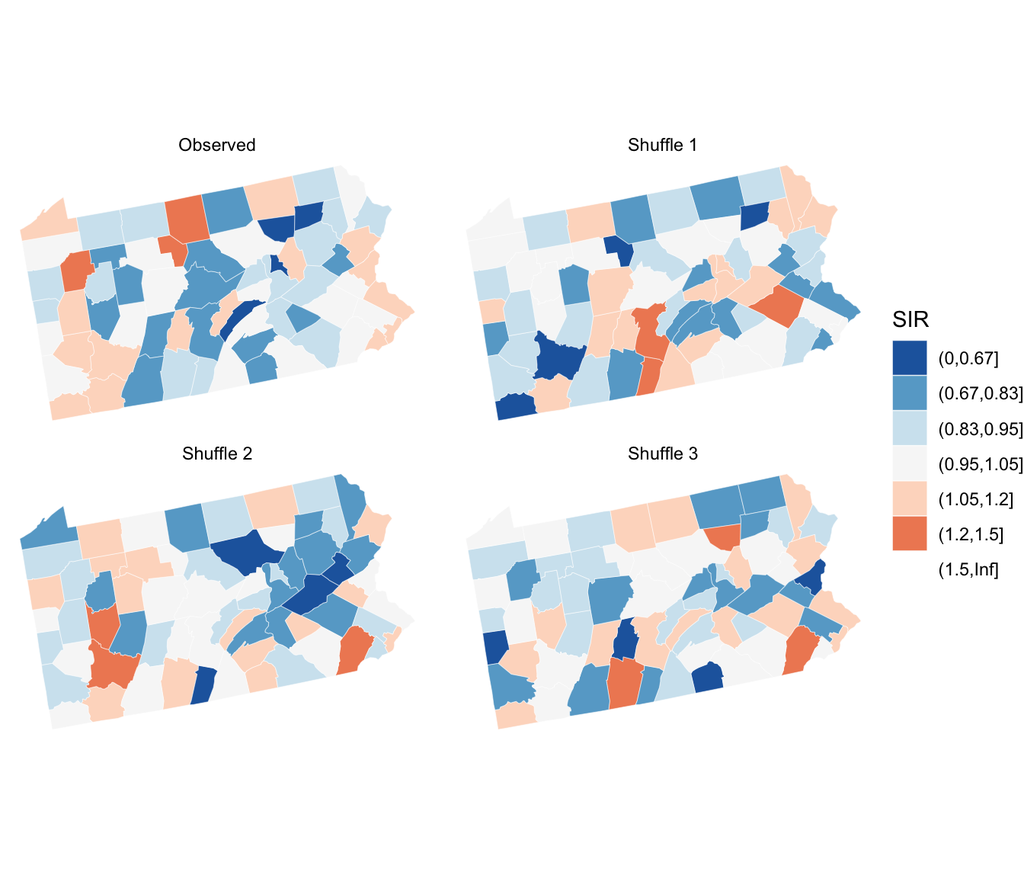

Figure 5: The real SIR map (top left) and three random shufflings of the same 67 values.

```r
set.seed(374)
shuffled <- bind_rows(
  pa |> mutate(panel = "Observed"),
  pa |> mutate(SIR = sample(SIR), panel = "Shuffle 1"),
  pa |> mutate(SIR = sample(SIR), panel = "Shuffle 2"),
  pa |> mutate(SIR = sample(SIR), panel = "Shuffle 3")
)

ggplot(shuffled) +
  geom_sf(aes(fill = cut(SIR, sir_breaks)), colour = "white", linewidth = 0.1) +
  sir_fill +
  facet_wrap(~ panel) +
  theme_void()
```

Same values, same colours, different arrangement. Can you pick out the real map? If not easily, the pattern may be weak. Moran’s I turns this eyeball test into a number.

## 4.2 Do it 999 times

`moran.mc()` shuffles the values 999 times, computes I each time, and compares the observed I with the shuffled ones.

```r
set.seed(374)
mc <- moran.mc(pa$SIR, lw, nsim = 999)
mc
```

```
    Monte-Carlo simulation of Moran I

data:  pa$SIR
weights: lw
number of simulations + 1: 1000

statistic = -0.01056, observed rank = 552, p-value = 0.448
alternative hypothesis: greater
```

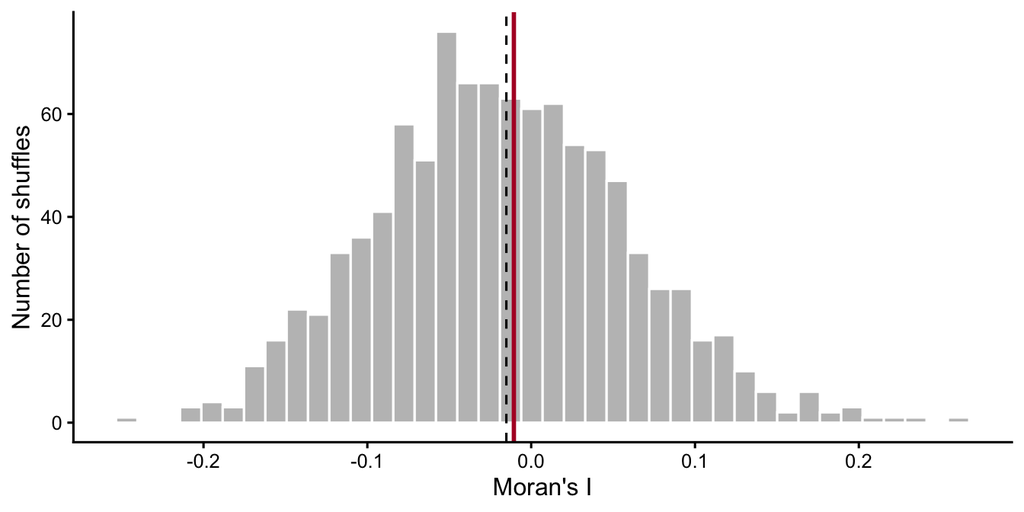

Figure 6: Moran’s I under 999 random shufflings (grey) and the observed value (red).

```r
sims <- data.frame(I = head(mc$res, -1))        # last element is the observed I

ggplot(sims, aes(I)) +
  geom_histogram(bins = 40, fill = "grey75", colour = "white") +
  geom_vline(xintercept = mc$statistic, colour = "#b2182b", linewidth = 1) +
  geom_vline(xintercept = -1 / (nrow(pa) - 1), linetype = "dashed") +
  labs(x = "Moran's I", y = "Number of shuffles")
```

The pseudo *p*-value counts how many shuffles did at least as well as the real map:

$$p = \frac{R + 1}{999 + 1},$$

where $R$ is the number of shuffled I’s at or above the observed one. Here $p =$ 0.45. With 999 shuffles, the smallest possible value is 0.001; more shuffles give finer resolution, not stronger evidence.

**ImportantSIRs are not equally reliable**

The shuffle treats Forest County (a handful of expected cases) and Philadelphia (over a thousand) as interchangeable. Small counties produce extreme SIRs by chance, and those extremes can create or hide apparent clustering. An Empirical Bayes version of Moran’s I (`spdep::EBImoran.mc()`, Assunção & Reis 1999) adjusts for this; we return to it with smoothing.

# 5 Local Moran’s I (LISA)

## 5.1 From one number to 67

Global I says *whether* the map is clustered, not *where*. The local version gives each county its own value:

$$I_i \propto (x_i - \bar x) \times \text{average of } (x_j - \bar x) \text{ over neighbours } j.$$

Positive $I_i$: the county resembles its neighbours (High-High or Low-Low). Negative $I_i$: it differs from them (High-Low or Low-High). The local values average to the global I — each county’s share of the overall pattern.

## 5.2 Conditional permutation

Significance is again simulated, with one twist: county $i$ is **held fixed** and only the other values are shuffled around it. This asks whether $i$’s particular neighbourhood is unusual, given $i$’s own value.

```r
set.seed(374)
lisa <- localmoran_perm(pa$SIR, lw, nsim = 999)

pa <- pa |>
  mutate(
    Ii    = lisa[, "Ii"],
    p_sim = lisa[, "Pr(z != E(Ii)) Sim"],                     # simulation-based p
    quad  = as.character(attr(lisa, "quadr")$mean)            # scatterplot quadrant
  )

c(mean_local = mean(pa$Ii), global = unname(mi$estimate[1]))  # same number
```

```
 mean_local      global
-0.01055968 -0.01055968
```

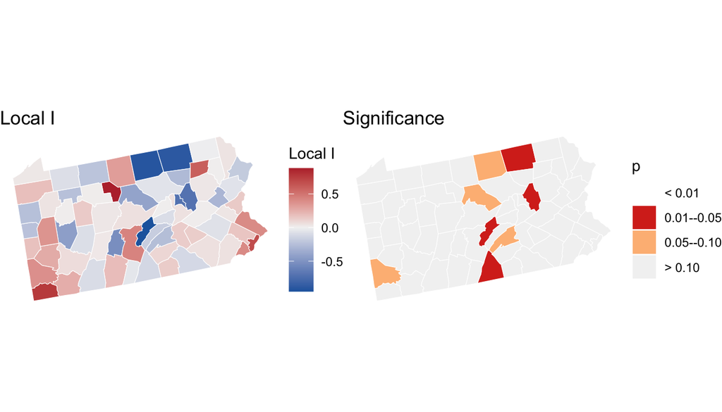

Figure 7: Local Moran’s I (left) and its simulated p-value (right).

```r
m_Ii <- ggplot(pa) +
  geom_sf(aes(fill = Ii), colour = "white", linewidth = 0.2) +
  scale_fill_gradient2(low = "#2166ac", mid = "grey95", high = "#b2182b", name = "Local I") +
  labs(title = "Local I")

m_p <- ggplot(pa) +
  geom_sf(aes(fill = cut(p_sim, c(0, 0.01, 0.05, 0.1, 1))), colour = "white", linewidth = 0.2) +
  scale_fill_manual(values = c("#7f0000", "#d7301f", "#fdbb84", "grey95"),
                    labels = c("< 0.01", "0.01--0.05", "0.05--0.10", "> 0.10"),
                    drop = FALSE, name = "p") +
  labs(title = "Significance")

(m_Ii | m_p) & theme_void()
```

## 5.3 The LISA cluster map

Combining the two maps — quadrant for significant counties, grey otherwise — gives the classic LISA map.

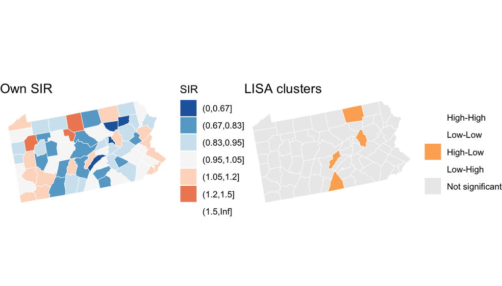

Figure 8: SIR (left) and LISA clusters at p < 0.05 (right).

```r
lisa_cols <- c("High-High" = "#d7191c", "Low-Low" = "#2c7bb6",
               "High-Low"  = "#fdae61", "Low-High" = "#abd9e9",
               "Not significant" = "grey92")

pa <- pa |>
  mutate(cluster = factor(if_else(p_sim < 0.05, quad, "Not significant"),
                          levels = names(lisa_cols)))

m_lisa <- ggplot(pa) +
  geom_sf(aes(fill = cluster), colour = "white", linewidth = 0.2) +
  scale_fill_manual(values = lisa_cols, drop = FALSE, name = NULL) +
  labs(title = "LISA clusters")

(m_own | m_lisa) & theme_void()
```

```r
pa |>
  st_drop_geometry() |>
  filter(cluster != "Not significant") |>
  arrange(cluster, p_sim) |>
  transmute(county, cluster, O, E = round(E, 1), SIR = round(SIR, 2),
            Ii = round(Ii, 2), p_sim)
```

| county | cluster | O | E | SIR | Ii | p_sim |
| --- | --- | --- | --- | --- | --- | --- |
| franklin | High-Low | 105 | 109.9 | 0.96 | -0.12 | 0.030 |
| columbia | High-Low | 58 | 53.3 | 1.09 | -0.71 | 0.032 |
| mifflin | High-Low | 45 | 40.8 | 1.10 | -0.95 | 0.042 |
| bradford | High-Low | 59 | 53.2 | 1.11 | -0.89 | 0.048 |

- **High-High** (hot spot): high SIR, high-SIR neighbours.
- **Low-Low** (cold spot): low SIR, low-SIR neighbours.
- **High-Low / Low-High** (spatial outliers): a county that breaks from its surroundings.

A High-High county is the *centre* of a cluster; its neighbours belong to the cluster but need not be significant themselves.

## 5.4 How much should we believe it?

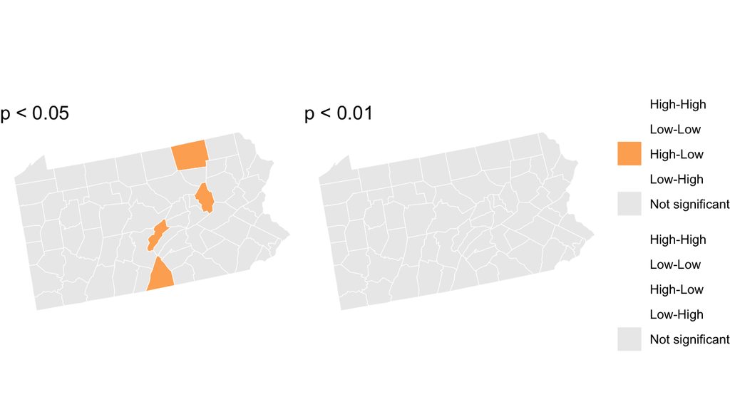

Figure 9: LISA clusters at p < 0.05 (left) and p < 0.01 (right).

```r
m_strict <- pa |>
  mutate(cluster = factor(if_else(p_sim < 0.01, quad, "Not significant"),
                          levels = names(lisa_cols))) |>
  ggplot() +
  geom_sf(aes(fill = cluster), colour = "white", linewidth = 0.2) +
  scale_fill_manual(values = lisa_cols, drop = FALSE, name = NULL) +
  labs(title = "p < 0.01")

(m_lisa + labs(title = "p < 0.05") | m_strict) +
  plot_layout(guides = "collect") & theme_void()
```

**Warning67 tests, not one**

At $p < 0.05$, about $0.05 \times 67 \approx 3$ counties would be flagged even if lung cancer risk had no spatial structure at all. Neighbouring tests also share data, so they are not independent. Treat LISA output as a map of places worth a closer look, not as a list of confirmed clusters. Clusters that survive a stricter threshold, involve counties with large $E_i$, and make epidemiological sense deserve the most attention.

# At home exercise: fifteen minutes

1. Replace queen contiguity with the four nearest neighbours (`knn2nb(knearneigh(st_coordinates(pts), k = 4))`). Does global I change much? Does the LISA map?
2. In the LISA table, which flagged counties have $E_i < 20$? Would you report them to a county health officer? Answer in one sentence.
3. Explain, in one sentence for a non-specialist, what a High-Low outlier means.

# Key takeaways

1. Spatial autocorrelation needs a definition of neighbours; with row-standardized weights, the spatial lag is the neighbours’ average.
2. Global Moran’s I is the slope of the Moran scatterplot: one number for the whole map.
3. Permutation answers “compared to what?”: shuffle the values, recompute, and see where the observed I falls.
4. Local Moran’s I locates hot spots, cold spots, and outliers, using conditional permutation for each county.
5. Raw SIRs differ in reliability, and LISA runs many tests at once; read both statistics with that in mind.

# References

Anselin, L. (1995). Local indicators of spatial association—LISA. *Geographical Analysis*, 27(2), 93–115.

Assunção, R. M., & Reis, E. A. (1999). A new proposal to adjust Moran’s I for population density. *Statistics in Medicine*, 18(16), 2147–2162.

Bivand, R. S., & Wong, D. W. S. (2018). Comparing implementations of global and local indicators of spatial association. *TEST*, 27(3), 716–748.

Cliff, A. D., & Ord, J. K. (1981). *Spatial processes: Models and applications*. Pion.

Moran, P. A. P. (1950). Notes on continuous stochastic phenomena. *Biometrika*, 37(1/2), 17–23.

Rogerson, P., & Yamada, I. (2009). *Statistical detection and surveillance of geographic clusters*. Chapman & Hall/CRC, Ch. 3–4.